# FractalCity Tutorial

**Edition:** 1

**Publucation year:** 2023

## Author

- Renan Lucas Fagundes, Universidade Federal de Lavras, UFLA, MG.

```python
#![No-video-title-fdown.net.gif](attachment:No-video-title-fdown.net.gif)
```

## Content

**1 Imports**

- 1.1 Versions

**2 Read Data**

**3 Generating the Street Network**

- 3.1 Visualizing the Street Network
- 3.2 $\mu$-number (cyclomatic)
- 3.3 $\alpha$-number
- 3.4 $\beta$-number
- 3.5 $\gamma$-number
- 3.6 Street Network Area (convex hull)
- 3.7 Street Network Perimeter (convex hull)

**4 Applying the 'SandBox' Method**

- 4.1 Street Network
  - 4.1.1 Vizualizing the Schema
  - 4.1.2 Plot the Data and Average
  - 4.1.3 Generalized Fractal Dimension
  - 4.1.4 Box-counting, Information and Correlation Fractal Dimensions
  - 4.1.5 Mass Exponents
  - 4.1.6 Multifractal Spectrum
- 4.2 Population
  - 4.2.1 Vizualizing the Schema
  - 4.2.2 Plot the Data and Average
  - 4.2.3 Generalized Fractal Dimension
  - 4.2.4 Box-counting, Information and Correlation Fractal Dimensions
  - 4.2.5 Mass Exponents
  - 4.2.6 Multifractal Spectrum

**5 Chemical Distance**

- 5.1 Efficiency Fractal Dimension
- 5.2 Average Straightness
- 5.3 Average Sinuosity

**6 Street Network and Population Plot**

**References**

## 1. Imports

```python
import numpy as np
import math
import pandas as pd
import geopandas as gpd
import networkx as nx
import powerlaw
import shapely.ops as so
import shapely.wkt
import matplotlib.pyplot as plt

from shapely import ops
from shapely.geometry import Point, box, MultiPoint, LineString, Polygon, MultiPolygon, MultiLineString, GeometryCollection
from shapely.strtree import STRtree

from FractalCity import *
```

### 1.1 Versions

```python
np.__version__, pd.__version__, gpd.__version__, nx.__version__, powerlaw.__version__, shapely.__version__
```

```
('1.19.5', '1.1.5', '0.7.0', '2.5.1', '1.5', '1.8.4')
```

## 2 Read Data

```python
data = ReadData('/home/renan/Documentos/Análise de dados/')
```

```python
df_nodes, df_links = data.read_nodes_and_links('Lavras', 'MG', 'Sudeste')
```

```python
df_nodes.info()
```

```
<class 'pandas.core.frame.DataFrame'>
RangeIndex: 3510 entries, 0 to 3509
Data columns (total 6 columns):
 #   Column    Non-Null Count  Dtype
---  ------    --------------  -----
 0   osmid     3510 non-null   int64
 1   y         3510 non-null   float64
 2   x         3510 non-null   float64
 3   lon       3510 non-null   float64
 4   lat       3510 non-null   float64
 5   geometry  3510 non-null   object
dtypes: float64(4), int64(1), object(1)
memory usage: 150.9+ KB
```

```python
df_nodes.head()
```

|  | osmid | y | x | lon | lat | geometry |
| --- | --- | --- | --- | --- | --- | --- |
| 0 | 353501750 | 7.650208e+06 | 499626.949178 | -45.003596 | -21.249785 | POINT (-45.0035955 -21.2497847) |
| 1 | 1431958418 | 7.650181e+06 | 499606.364850 | -45.003794 | -21.250029 | POINT (-45.0037939 -21.2500289) |
| 2 | 1432666855 | 7.650172e+06 | 499627.344245 | -45.003592 | -21.250102 | POINT (-45.0035917 -21.2501023) |
| 3 | 353502592 | 7.649695e+06 | 500488.805280 | -44.995289 | -21.254418 | POINT (-44.9952887 -21.254418) |
| 4 | 3901738964 | 7.649714e+06 | 500355.526301 | -44.996573 | -21.254240 | POINT (-44.9965733 -21.2542403) |

```python
df_links.info()
```

```
<class 'pandas.core.frame.DataFrame'>
RangeIndex: 9187 entries, 0 to 9186
Data columns (total 4 columns):
 #   Column    Non-Null Count  Dtype
---  ------    --------------  -----
 0   u         9187 non-null   int64
 1   v         9187 non-null   int64
 2   length    9187 non-null   float64
 3   geometry  9187 non-null   object
dtypes: float64(1), int64(2), object(1)
memory usage: 251.3+ KB
```

```python
df_links.head()
```

|  | u | v | length | geometry |
| --- | --- | --- | --- | --- |
| 0 | 353501750 | 1431958418 | 36.585741 | LINESTRING (-45.0035955 -21.2497847, -45.00379... |
| 1 | 353501750 | 1432666855 | 37.936648 | LINESTRING (-45.0035955 -21.2497847, -45.00359... |
| 2 | 1431958418 | 1432666855 | 24.155855 | LINESTRING (-45.0037939 -21.25002890000001, -4... |
| 3 | 1431958418 | 1432666850 | 66.633354 | LINESTRING (-45.0037939 -21.25002890000001, -4... |
| 4 | 1432666855 | 1430927687 | 142.154239 | LINESTRING (-45.0035917 -21.25010230000001, -4... |

## 3 Generating the Street Network

```python
sn = StreetNetwork()
```

```python
#help(sn)
```

```python
G = sn.generate_network(df_nodes, df_links)
```

### 3.1 Visualizing the Street Network

```python
kwargs = {'figsize': (8,8),
          'node_size': 0,
          'edge_width': 1}
```

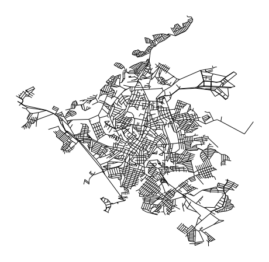

```python
sn.plot_network(G, kwargs)
```

### 3.2 $\mu$-number (cyclomatic)

```python
sn.cyclomatic_number(G)
```

```
1616
```

### 3.3 $\alpha$-number

```python
sn.alpha_number(G)
```

```
0.23036350677120457
```

### 3.4 $\beta$-number

```python
sn.beta_number(G)
```

```
1.46011396011396
```

### 3.5 $\gamma$-number

```python
sn.gamma_number(G)
```

```
0.4869821360699354
```

### 3.6 Street Network Area (convex hull)

```python
sn.network_area(G)/10e6
```

```
24.262611687709807
```

### 3.7 Street Network Perimeter (convex hull)

```python
sn.network_perimeter(G)/10e3
```

```
5.969933874939586
```

## 4 Applying the 'SandBox' Method

```python
sb = SandBox()
```

```python
#help(sb)
```

### 4.1 Street Network

```python
lon_red, lat_red, lon_blue, lat_blue, lon_gray, lat_gray = sb.generate_grid(df_nodes)
```

```python
sb.generate_points(lon_red, lat_red, lon_blue, lat_blue, lon_gray, lat_gray)
```

```
Points created!
```

```python
sb.apply_sandbox_on_street_network(num_div_rmin = 50, num_div_rmax = 2, num_intervals = 50, fraction = 4)
```

```
Sandbox method successfully applied!
```

```python
street_network_data = sb.get_sandbox_data_from_street_network()
```

#### 4.1.1 Vizualizing the Schema

```python
lon_p, lat_p = [pos[0] for pos in street_network_data['analized_points']], [pos[1] for pos in street_network_data['analized_points']]
```

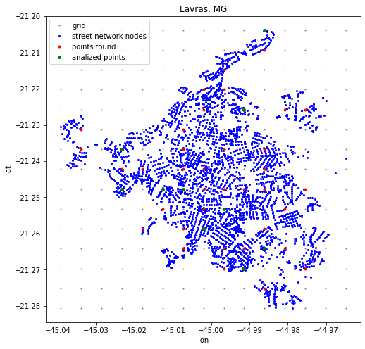

```python
fig, ax = plt.subplots(figsize=(8,8))

ax.plot(lon_gray, lat_gray, 'o', markersize = 1, color='gray', label = 'grid')
ax.plot(lon_blue, lat_blue, 'o', markersize = 2, color='blue', label = 'street network nodes')
ax.plot(lon_red, lat_red, 'o', markersize = 3, color='red', label = 'points found')
ax.plot(lon_p, lat_p, 'o', markersize = 4, color='green', label = 'analized points')

ax.set_xlabel('lon')
ax.set_ylabel('lat')

plt.title('Lavras, MG')
plt.legend()

plt.show()
```

#### 4.1.2 Plot the Data and Average

```python
average = [np.mean([street_network_data['N'][i][j] for i in range(len(street_network_data['N']))]) for j in range(len(street_network_data['N'][0]))]
```

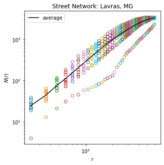

```python
fig, ax = plt.subplots(figsize=(5,5))

ax.plot(street_network_data['r'], street_network_data['N'], 'o' , fillstyle = 'none')
ax.plot(street_network_data['r'][0], average, 'k-', label = 'average')

ax.set_xscale('log')
ax.set_yscale('log')

ax.set_xlabel(r'$r$')
ax.set_ylabel(r'$N(r)$')

plt.title('Street Network: Lavras, MG')
plt.legend()

plt.show()
```

#### 4.1.3 Generalized Fractal Dimension

```python
moment_list = list(np.linspace(-10, 10, 100))
```

```python
dict_gen_dim = sb.street_network_generalized_dimension(street_network_data, moment_list)
```

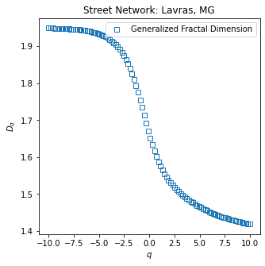

```python
fig, ax = plt.subplots(figsize=(5,5))

ax.plot(moment_list, dict_gen_dim['gen_dim_street_network'], 's', fillstyle='none', label = 'Generalized Fractal Dimension')

ax.set_xlabel(r'$q$')
ax.set_ylabel(r'$D_{q}$')

plt.title('Street Network: Lavras, MG')
plt.legend()

plt.show()
```

#### 4.1.4 Box-counting, Information and Correlation Fractal Dimensions

```python
q0_index = moment_list.index(0.10101010101010033)
q1_index = moment_list.index(1.1111111111111107)
q2_index = moment_list.index(2.121212121212121)

D0 = round(dict_gen_dim['gen_dim_street_network'][q0_index],2)
D0_std = round(dict_gen_dim['gen_dim_street_network_std'][q0_index], 2)
D0_r2 = round(dict_gen_dim['gen_dim_street_network_r2'][q0_index],2)


D1 = round(dict_gen_dim['gen_dim_street_network'][q1_index],2)
D1_std = round(dict_gen_dim['gen_dim_street_network_std'][q1_index], 2)
D1_r2 = round(dict_gen_dim['gen_dim_street_network_r2'][q1_index],2)

D2 = round(dict_gen_dim['gen_dim_street_network'][q2_index],2)
D2_std = round(dict_gen_dim['gen_dim_street_network_std'][q2_index], 2)
D2_r2 = round(dict_gen_dim['gen_dim_street_network_r2'][q2_index],2)
```

```python
print(f'Box-counting: {D0,D0_std,D0_r2}\nInformation: {D1,D1_std,D1_r2}\nCorrelation: {D2,D2_std,D2_r2}', sep='\n')
```

```
Box-counting: (1.65, 0.03, 1.0)
Information: (1.58, 0.04, 0.99)
Correlation: (1.53, 0.06, 0.98)
```

#### 4.1.4 Mass Exponents

```python
tau_list = sb.street_network_mass_exponent(dict_gen_dim['gen_dim_street_network'], moment_list)
```

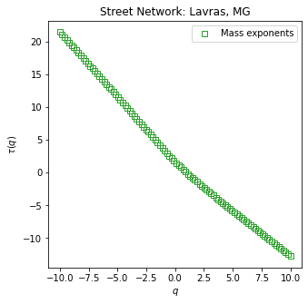

```python
fig, ax = plt.subplots(figsize=(5,5))

ax.plot(moment_list, tau_list, 's', fillstyle='none', color='tab:green', label = 'Mass exponents')

ax.set_xlabel(r'$q$')
ax.set_ylabel(r'$\tau(q)$')

plt.title('Street Network: Lavras, MG')
plt.legend()

plt.show()
```

#### 4.1.5 Multifractal Spectrum

```python
alpha, falpha = sb.street_network_multifractal_spectrum(tau_list, moment_list)
```

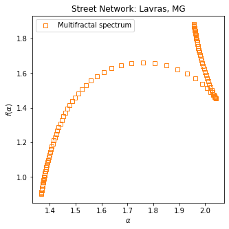

```python
fig, ax = plt.subplots(figsize=(5,5))

ax.plot(alpha, falpha, 's', fillstyle='none', color = 'tab:orange', label = 'Multifractal spectrum')

ax.set_xlabel(r'$\alpha$')
ax.set_ylabel(r'$f(\alpha)$')

plt.title('Street Network: Lavras, MG')
plt.legend()

plt.show()
```

### 4.2 Population

```python
pol, popul = data.read_polygons_populations('Lavras', 'MG', 'Sudeste')
```

```python
population_data = sb.apply_sandbox_on_population(pol, popul, lon_red, lat_red, lon_gray, lat_gray, num_div_rmin = 50, num_div_rmax = 2, num_intervals = 50, fraction = 4)
```

```
/home/renan/Documentos/Análise de dados/FractalCity.py:1058: ShapelyDeprecationWarning: STRtree will be changed in 2.0.0 and will not be compatible with versions < 2.
  tree = STRtree(multipolygon.geoms)
```

#### 4.2.1 Vizualizing the schema

```python
lon_p, lat_p = [pos[0] for pos in population_data['analized_points']], [pos[1] for pos in population_data['analized_points']]
```

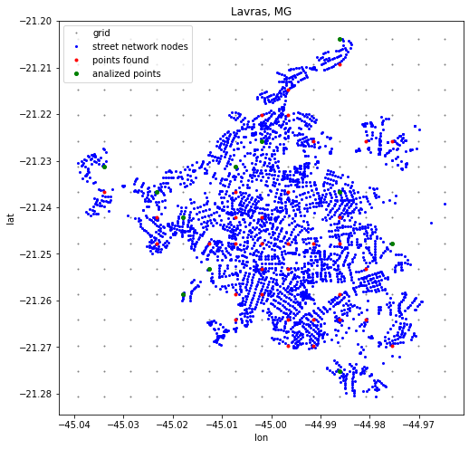

```python
fig, ax = plt.subplots(figsize=(8,8))

ax.plot(lon_gray, lat_gray, 'o', markersize = 1, color='gray', label = 'grid')
ax.plot(lon_blue, lat_blue, 'o', markersize = 2, color='blue', label = 'street network nodes')
ax.plot(lon_red, lat_red, 'o', markersize = 3, color='red', label = 'points found')
ax.plot(lon_p, lat_p, 'o', markersize = 4, color='green', label = 'analized points')

ax.set_xlabel('lon')
ax.set_ylabel('lat')

plt.title('Lavras, MG')
plt.legend()

plt.show()
```

#### 4.2.2 Plot the data and the average

```python
average = [np.mean([population_data['N'][i][j] for i in range(len(population_data['N']))]) for j in range(len(population_data['N'][0]))]
```

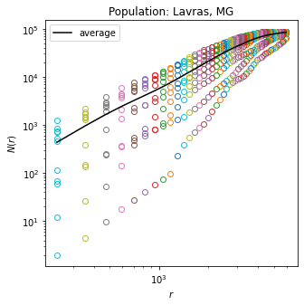

```python
fig, ax = plt.subplots(figsize=(5,5))

ax.plot(population_data['r'], population_data['N'], 'o' , fillstyle = 'none')
ax.plot(population_data['r'][0], average, 'k-', label = 'average')

ax.set_xscale('log')
ax.set_yscale('log')

ax.set_xlabel(r'$r$')
ax.set_ylabel(r'$N(r)$')

plt.title('Population: Lavras, MG')
plt.legend()

plt.show()
```

#### 4.2.3 Generalized Fractal Dimension

```python
dict_gen_dim = sb.population_generalized_dimension(population_data, moment_list)
```

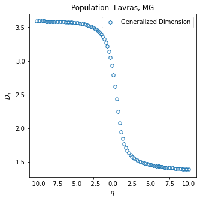

```python
fig, ax = plt.subplots(figsize=(5,5))

ax.plot(moment_list, dict_gen_dim['gen_dim_population'], 'h', fillstyle='none', label = 'Generalized Dimension')

ax.set_xlabel(r'$q$')
ax.set_ylabel(r'$D_{q}$')

plt.title('Population: Lavras, MG')
plt.legend()

plt.show()
```

#### 4.2.4 Box-counting, Information and Correlation Fractal Dimensions

```python
q0_index = moment_list.index(0.10101010101010033)
q1_index = moment_list.index(1.1111111111111107)
q2_index = moment_list.index(2.121212121212121)

D0 = round(dict_gen_dim['gen_dim_population'][q0_index],2)
D0_std = round(dict_gen_dim['gen_dim_population_std'][q0_index], 2)
D0_r2 = round(dict_gen_dim['gen_dim_population_r2'][q0_index],2)


D1 = round(dict_gen_dim['gen_dim_population'][q1_index],2)
D1_std = round(dict_gen_dim['gen_dim_population_std'][q1_index], 2)
D1_r2 = round(dict_gen_dim['gen_dim_population_r2'][q1_index],2)

D2 = round(dict_gen_dim['gen_dim_population'][q2_index],2)
D2_std = round(dict_gen_dim['gen_dim_population_std'][q2_index], 2)
D2_r2 = round(dict_gen_dim['gen_dim_population_r2'][q2_index],2)
```

```python
print(f'Box-counting: {D0,D0_std,D0_r2}\nInformation: {D1,D1_std,D1_r2}\nCorrelation: {D2,D2_std,D2_r2}', sep='\n')
```

```
Box-counting: (2.79, 0.1, 0.98)
Information: (1.95, 0.06, 0.99)
Correlation: (1.63, 0.05, 0.99)
```

#### 4.2.5 Mass Exponents

```python
tau_list = sb.population_mass_exponent(dict_gen_dim['gen_dim_population'], moment_list)
```

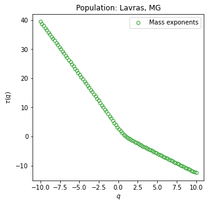

```python
fig, ax = plt.subplots(figsize=(5,5))

ax.plot(moment_list, tau_list, 'h', fillstyle='none', color='tab:green', label = 'Mass exponents')

ax.set_xlabel(r'$q$')
ax.set_ylabel(r'$\tau(q)$')

plt.title('Population: Lavras, MG')
plt.legend()

plt.show()
```

#### 4.2.6 Multifractal Spectrum

```python
alpha, falpha = sb.population_multifractal_spectrum(tau_list, moment_list)
```

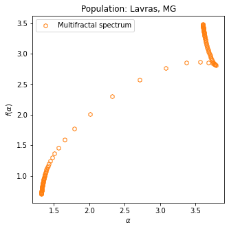

```python
fig, ax = plt.subplots(figsize=(5,5))

ax.plot(alpha, falpha, 'h', fillstyle='none', color = 'tab:orange', label = 'Multifractal spectrum')

ax.set_xlabel(r'$\alpha$')
ax.set_ylabel(r'$f(\alpha)$')

plt.title('Population: Lavras, MG')
plt.legend()

plt.show()
```

## 5 Chemical Distance

```python
dict_routes = sn.generate_routes(G)
```

```python
euclidian_distance = dict_routes['euclidian_distance']
chemical_distance = dict_routes['chemical_distance']
average_euclidian_distance = dict_routes['average_euclidian_distance']
chemical_routes = dict_routes['chemical_routes']
chemical_routes_pos = dict_routes['chemical_routes_pos']
```

### 5.1 Efficiency Fractal Dimension

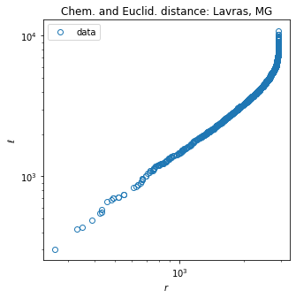

```python
fig, ax = plt.subplots(figsize=(5,5))

ax.plot(average_euclidian_distance, chemical_distance, 'o', fillstyle='none', color = 'tab:blue', label = 'data')

ax.set_xscale('log')
ax.set_yscale('log')

ax.set_xlabel(r'$r$')
ax.set_ylabel(r'$\ell$')

plt.title('Chem. and Euclid. distance: Lavras, MG')
plt.legend()

plt.show()
```

### 5.2 Average Straightness

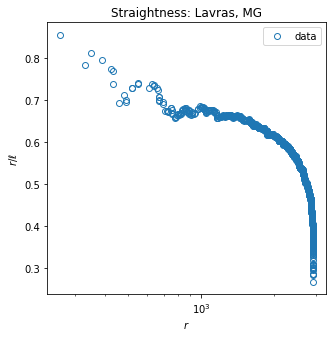

```python
fig, ax = plt.subplots(figsize=(5,5))

average_straightness = np.divide(average_euclidian_distance, chemical_distance)

ax.plot(average_euclidian_distance, average_straightness, 'o', fillstyle='none', color = 'tab:blue', label = 'data')

ax.set_xscale('log')
#ax.set_yscale('log')

ax.set_xlabel(r'$r$')
ax.set_ylabel(r'$r/\ell$')

plt.title('Straightness: Lavras, MG')
plt.legend()

plt.show()
```

### 5.3 Average Sinuosity

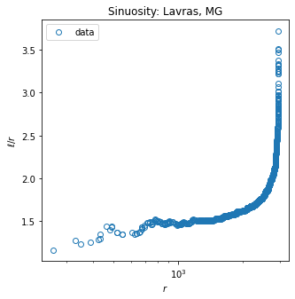

```python
fig, ax = plt.subplots(figsize=(5,5))

average_sinuosity = np.divide(chemical_distance, average_euclidian_distance)

ax.plot(average_euclidian_distance, average_sinuosity, 'o', fillstyle='none', color = 'tab:blue', label = 'data')

ax.set_xscale('log')
#ax.set_yscale('log')

ax.set_xlabel(r'$r$')
ax.set_ylabel(r'$\ell / r$')

plt.title('Sinuosity: Lavras, MG')
plt.legend()

plt.show()
```

## 6 Street Network and Population Plot

```python
psp = PlotStreetPopulation(pol, popul, df_nodes, df_links)
```

```python
#help(psp)
```

```python
kwargs = {'legend': True,
          'markersize': 2,
          'linewidth': 1,
          'node_color': 'white',
          'edge_color': 'white',
          'figsize': (8, 8),
          'xlim': (-45.05, -44.95),
          'ylim': (-21.29, -21.20),
          'xlabel': 'lon',
          'ylabel': 'lat',
          'legend_kwds': {"label": "Population in 2010", "orientation": "vertical"},
          'cmap': 'viridis'}
```

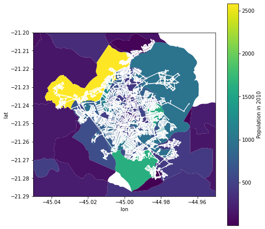

```python
psp.plot_geo_population_network(kwargs)
```

## References

[1] T. C. Halsey, M. H. Jensen, L. P. Kadanoff, I. Procaccia, and B. I. Shraiman, “Fractal measures and their singularities: The characterization of strange sets,” Phys. Rev. A, vol. 33, pp. 1141–1151, Feb 1986.

[2] T. T ́el, ́Agnes F ̈ul ̈op, and T. Vicsek, “Determination of fractal dimensions for geometrical multifractals,” Physica A: Statistical Mechanics and its Applications, vol. 159, no. 2, pp. 155–166, 1989.

[3] S. Appleby, “Multifractal characterization of the distribution pattern of the human population,” Geographical Analysis, no. 28, pp. 147–160, 1996.

[4] S. G. De Bartolo, R. Gaudio, and S. Gabriele, “Multifractal analysis of river networks: Sandbox approach,” Water Resources Research, vol. 40, no. 2, 2004.

[5] R. Murcio, A. P. Masucci, E. Arcaute, and M. Batty, “Multifractal to monofractal evolution of the london street network,” Phys. Rev. E, vol. 92, p. 062130, Dec 2015.

[6] F. S ́em ́ecurbe, C. Tannier, and S. G. Roux, “Spatial distribution of human population in france: Exploring the modifiable areal unit problem using multifractal analysis,” Geographical Analysis, vol. 48, no. 3, pp. 292–313, 2016.

[7] H. Salat, R. Murcio, and E. Arcaute, “Multifractal methodology,” Physica A: Statistical Mechanics and its Applications, vol. 473, pp. 467–487, 2017.

[8] E. Rosenberg, Fractal Dimensions of Networks. Springer Cham, 1 ed., 2021.

[9] Y. Chen, “Two sets of simple formulae to estimating fractal dimension of irregular boundaries,” Mathematical Problems in Engineering, no. 15, 2020.

[10] E. Strano, F. Simini, and M. De Nadai, “The agglomeration and dispersion dichotomy of human settlements on earth,” Sci Rep, no. 11, p. 23289, 2021.

[11] Z. Song, Y. Chen, and M. Bo, “Multifractal characteristics analysis of spatial state of prefecture-level cities in china.,” Appl. Spatial Analysis, 2023.

[12] K. Falconer, Fractal geometry: mathematical foundations and applications. John Wiley & Sons, 2004.

[13] K. Falconer, Fractals. Oxford University Press, 2013.

[14] H. Zhang, T. Lan, and Z. Li, “Fractal evolution of urban street networks in form and structure: a case study of Hong Kong,” International Journal of Geographical Information Science, vol. 36, no. 6, pp. 1100–1118, 2022.

[15] K. Shirriff, “Chapter 4 - generating fractals from voronoi diagrams,” in Chaos and Fractals (C. A. Pickover, ed.), pp. 23–25, Amsterdam: Elsevier Science, 1998.

[16] A. Bunde and S. Havlin, Fractals and Disordered System. Springer, 1992.

[17] A. Bunde and S. Havlin, Fractals in Science. Springer Berlin, Heidelberg, 1994.

[18] B. Mandelbrot, W. H. Freeman, and Company, The Fractal Geometry of Nature. Einaudi paperbacks, Henry Holt and Company, 1983.

[19] T. Fernandes, J. Filho, and I. Lopes, “Fractal signature of coronaviruses related to severe acute respiratory syndrome,” Research on Biomedical Engineering, vol. 38, 06 2020.

[20] T. Nakayama, K. Yakubo, and R. L. Orbach, “Dynamical properties of fractal networks: Scaling, numerical simulations, and physical realizations,” Rev. Mod. Phys., vol. 66, pp. 381–443, Apr 1994.

[21] B. Moore and L. P. Dasi, “Multi-fractal nature of human left ventricular trabeculae: Possible biomechanical role?,” Chaos, Solitons Fractals, vol. 57, pp. 19–23, 2013.

[22] P. Peebles, “The fractal galaxy distribution,” Physica D: Nonlinear Phenomena, vol. 38, no. 1, pp. 273–278, 1989.

[23] R. I. Abid, A. Tortum, and A. Atalay, “Fractal dimensions of road networks in amman metropolitan districts,” Alexandria Engineering Journal, vol. 60, no. 4, pp. 4203–4212, 2021.

[24] M. F. Barnsley and S. Demko, “Iterated function systems and the global construction of fractals,” Proceedings of the Royal Society of London. Series A, Mathematical and Physical Sciences, vol. 399, no. 1817, pp. 243–275, 1985.

[25] J. Alstott, E. Bullmore, and D. Plenz, “powerlaw: A python package for analysis of heavy-tailed distributions,” PLOS ONE, vol. 9, pp. 1–11, 01 2014.

[26] F. Jahanmiri and D. C. Parker, “An overview of fractal geometry applied to urban planning,” Land, vol. 11, no. 4, 2022.

[27] A. Clauset, C. R. Shalizi, and M. E. J. Newman, “Power-law distributions in empirical data,” SIAM Review, vol. 51, no. 4, pp. 661–703, 2009.

[28] A. Kartun-Giles, M. Barthelemy, and C. Dettmann, “Shape of shortest paths in random spatial networks,” Physical Review E , vol. 100, p. 2315, Sept. 2019.

[29] S. Chatterjee, “The universal relation between scaling exponents in first-passage perco- lation,” Annals of Mathematics, pp. 663–697, 2013.

[30] P. Bonacich, “Power and centrality: A family of measures,” American Journal of Soci- ology, vol. 92, no. 5, p. 1170–82, 1987.

[31] L. da F. Costa, F. A. Rodrigues, G. Travieso, and P. R. V. Boas, “Characterization of complex networks: A survey of measurements,” Advances in Physics, vol. 1, no. 56, pp. 167–242, 2007.

[32] A. S. d. Mata, “Complex Networks: a Mini-review,” Brazilian Journal of Physics, vol. 50, pp. 658–672, Oct. 2020.

[33] M. E. J. Newman, Networks: An Introduction. Oxford University Press, 2010.

[34] A. Sharifi, “Resilient urban forms: A review of literature on streets and street networks,” Building and Environment, vol. 147, pp. 171–187, 2019.

[35] P. Erd ̃os and A. R ́enyi, “On random graphs i.,” Publ. Math., p. 290, December 1959.

[36] D. Watts and S. Strogatz, “Collective dynamics of ‘small-world’ networks.,” Nature, vol. 393, p. 440–442, 1998.

[37] Z. Zhou, J. Yang, Y. Deng, and R. M. Ziff, “Shortest-path fractal dimension for percolation in two and three dimensions,” Phys. Rev. E, vol. 86, p. 061101, Dec 2012.

[38] R. C. Batac and M. T. Cirunay, “Shortest paths along urban road network peripheries,” Physica A: Statistical Mechanics and its Applications, vol. 597, p. 127255, 2022.

[39] A.-L. Barab ́Asi and H. E. Staley, Fractal Concepts in Surface Growth. Cambridge University Press, 1995.

[40] A.-L. Barabasi and R. Albert, “Albert, r.: Emergence of scaling in random networks.,” Science (New York, N.Y.), vol. 286, pp. 509–12, 11 1999.

[41] R. Albert and A.-L. Barab ́asi, “Statistical mechanics of complex networks,” Rev. Mod. Phys., vol. 74, pp. 47–97, Jan 2002.

[42] W. Garrison, “Connectivity of the interstate highway system.,” Papers of the Regional Science Association, p. 121–137, 6 1960.

[43] K. Kansky., “The structure of transportation networks: Relationships between network geography and regional characteristics.,” Chicago: University of Chicago, 1963. Research Paper No. 84., 1963.

[44] P. Haggett and R. Chorley., “Network analysis in geography.,” Arnold, London,, 1972.

[45] C. Ducruet and I. Lugo, “Structure and dynamics of transportation networks: Models, methods, and applications,” 08 2011.

[46] S. Lunag ́omez, S. C. Olhede, and P. J. Wolfe, “Modeling network populations via graph distances,” Journal of the American Statistical Association, vol. 116, no. 536, pp. 2023–2040, 2021.

[47] S. Lmmer, B. Gehlsen, and D. Helbing, “Scaling laws in the spatial structure of urban road networks,” Physica A: Statistical Mechanics and its Applications, vol. 363, no. 1, pp. 89–95, 2006. Information and Material Flows in Complex Networks.

[48] M. Li, R.-R. Liu, L. L ̈u, M.-B. Hu, S. Xu, and Y.-C. Zhang, “Percolation on complex networks: Theory and application,” Physics Reports, vol. 907, pp. 1–68, 2021. Percolation on complex networks: Theory and application.

[49] U. Brandes, S. P. Borgatti, and L. C. Freeman, “Maintaining the duality of closeness and betweenness centrality,” Social Networks, vol. 44, pp. 153–159, 2016.

[50] C. B. Evans, T.S., “Linking the network centrality measures closeness and degree,” Commun Phys, vol. 5, no. 172, 2022.

[51] C. Molinero and S. Thurner, “How the geometry of cities determines urban scaling laws,” Journal of the Royal Society interface, vol. 18, no. 176, p. 20200705, 2021.

[52] F. L. Ribeiro and D. Rybski, “Mathematical models to explain the origin of urban scaling laws,” Physics Reports, vol. 1012, pp. 1–39, 2023.

[53] M. Guo, L. Yang, F. Shen, L. Zhang, A. Li, Y. Cai, and C. Zhou, “Impact of socioeconomic environment and its interaction on the initial spread of COVID-19 in mainland China,” Geospatial Health, vol. 17, Mar. 2022.

[54] E. Arcaute, E. Hatna, P. Ferguson, H. Youn, A. Johansson, and M. Batty, “Constructing cities, deconstructing scaling laws,” Journal of the Royal Society interface, vol. 12, no. 102, 2015.

[55] W. R. Tobler, “A computer movie simulating urban growth in Detroid region,” Econo- mic Geography, vol. 46, pp. 234–240, 1970.

[56] P. H. N. Santos, M. G. Cruz, and W. F. S. Santos, “City science and urban planning: geoprocessing as an instrument for municipal strategic planning,” vol. 6, 2022.

[57] M. Batty, “The size, scale, and shape of cities,” Science (New York, N.Y.), vol. 319, pp. 769–71, 03 2008.

[58] M. Batty, The New Science of Cities. The MIT Press, 2013.

[59] M. Batty, “A theory of city size,” Science, vol. 340, no. 6139, pp. 1418–1419, 2013.

[60] S. G. Ortman, J. Lobo, and M. E. Smith, “Cities: Complexity, theory and history,” PLOS ONE, vol. 15, pp. 1–24, 12 2020.

[61] M. Lee and H. e. a. Barbosa, H.AND Youn, “Morphology of travel routes and the organization of cities.,” Nat Commun, vol. 8, 12 2017.

[62] M. Barthelemy, “The statistical physics of cities,” Nature Reviews Physics, vol. 1, no. 6, pp. 406–415, 2019.

[63] A. F. Siegenfeld and Y. Bar-Yam, “An introduction to complex systems science and its applications,” Complexity, vol. 2020, 2020.

[64] F. L. Ribeiro and W. R. Pereira, “A gentle introduction to scaling laws in biological systems,” arXiv preprint arXiv:2105.01540, 2021.

[65] E. Arcaute and J. J. Ramasco, “Recent advances in urban system science: Models and data,” PLOS ONE, vol. 17, pp. 1–16, 08 2022.

[66] Corral, G. Boleda, and R. Ferrer-i Cancho, “Zipf’s law for word frequencies: Word forms versus lemmas in long texts,” PLOS ONE, vol. 10, pp. 1–23, 07 2015.

[67] K. K. . M. B. Verscharen, D., “The multi-scale nature of the solar wind.,” Living Rev Sol Phys, no. 16, 2019.

[68] A. Johansen, E. Jacquet, J. Cuzzi, A. Morbidelli, and M. Gounelle, “New paradigms for asteroid formation,” Asteroids IV, 05 2015.

[69] F. Caccioli, P. Barucca, and T. Kobayashi, “Network models of financial systemic risk: A review,” Journal of Computational Social Science, vol. 1, 01 2018.

[70] D. A. Minton, C. I. Fassett, M. Hirabayashi, B. A. Howl, and J. E. Richardson, “The equilibrium size-frequency distribution of small craters reveals the effects of distal ejecta on lunar landscape morphology,” Icarus, vol. 326, pp. 63–87, 2019.

[71] D. McKenzie and M. Kennedy, “Power laws reveal phase transitions in landscape con- trols of fire regimes,” Nature communications, vol. 3, p. 726, 03 2012.

[72] ́A. Corral, A. Oss ́o, and J. Llebot, “Scaling of tropical-cyclone dissipation,” Nature Physics, vol. 6, pp. 693–696, Jan. 2010.

[73] S. Tebbens, “Landslide scaling: A review,” Earth and Space Science, vol. 7, 01 2020.

[74] M. Menabde, A. Seed, and G. Pegram, “A simple scaling model for extreme rainfall,” Water Resources Research, vol. 35, pp. 335–339, Jan. 1999.

[75] L. Bettencourt and G. West, “A unified theory of urban living,” Nature, vol. 467, pp. 912–3, 10 2010.

[76] L. M. A. Bettencourt, “The origins of scaling in cities,” Science, vol. 340, no. 6139, pp. 1438–1441, 2013.

[77] F. L. Ribeiro and W. R. L. S. Pereira, “A gentle introduction to scaling relations in biological systems,” Revista Brasileira de Ensino de F ́ısica, vol. 44, no. Rev. Bras. Ensino F ́ıs., 2022 44, p. e20210291, 2022.

[78] Y. Natalia, C. Faes, T. Neyens, P. Chys, N. Hammami, and G. Molenberghs, “Fractal dimension based geographical clustering of covid-19 time series data,” Scientific Reports, vol. 13, 03 2023.

[79] A. Stier, M. Berman, and L. Bettencourt, “Early pandemic covid-19 case growth rates increase with city size,” Urban Sustain, vol. 1, no. 31, 2021.